# Homework 5

## Elastic Net Tuning

```r
library(tidymodels)
library(tidyverse)
library(ISLR)
library(ISLR2)
library(discrim)
library(poissonreg)
library(corrr)
library(corrplot)
library(klaR)
library(pROC)
library(glmnet)
library(dplyr)
tidymodels_prefer()
```

```r
pokemon <- read.csv(file = "homework-5/data/pokemon.csv")
```

### Exercise 1

```r
library(janitor)

pokemon <- clean_names(pokemon)
head(pokemon)
```

```
##   x                  name type_1 type_2 total hp attack defense sp_atk sp_def
## 1 1             Bulbasaur  Grass Poison   318 45     49      49     65     65
## 2 2               Ivysaur  Grass Poison   405 60     62      63     80     80
## 3 3              Venusaur  Grass Poison   525 80     82      83    100    100
## 4 3 VenusaurMega Venusaur  Grass Poison   625 80    100     123    122    120
## 5 4            Charmander   Fire          309 39     52      43     60     50
## 6 5            Charmeleon   Fire          405 58     64      58     80     65
##   speed generation legendary
## 1    45          1     False
## 2    60          1     False
## 3    80          1     False
## 4    80          1     False
## 5    65          1     False
## 6    80          1     False
```

After using the clean_names() function, it changed the variable names to all appear as lowercase and replaced the periods with ’_’ which also represent spaces in the names themselves. clean_names() is useful because it allows all the variable names to follow the same format to avoid confusion especially when they are going to be called later on.

### Exercise 2

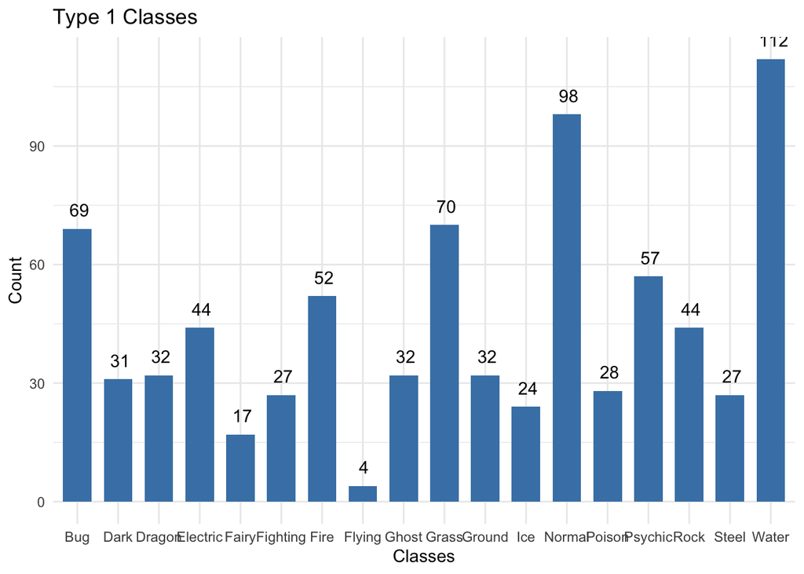

```r
type1bar <- ggplot(data = pokemon, aes(x = type_1)) +
  geom_bar(stat = "count", width = 0.7, fill = "steelblue")+
  theme_minimal()+
  geom_text(stat = 'count', aes(label = ..count..), hjust = .4, vjust = -1)+
  labs(title = "Type 1 Classes", x = "Classes", y = "Count")
type1bar
```

```r
pokemon <- pokemon %>%
  filter(type_1 == "Bug" | type_1 == "Fire" | type_1 == "Grass" | type_1 ==  "Normal" | type_1 ==  "Water" | type_1 == "Psychic")


pokemon$type_1 <- as.factor(pokemon$type_1)
pokemon$legendary <- as.factor(pokemon$legendary)
pokemon$generation <- as.factor(pokemon$generation)
```

### Exercise 3

```r
set.seed(0714)

# Initial Split
pokemon_split <- initial_split(pokemon, strata = type_1, prop = 0.7)
pokemon_split
```

```
## <Analysis/Assess/Total>
## <318/140/458>
```

```r
#Separate into training and testing
pokemon_train <- training(pokemon_split)
pokemon_test <- testing(pokemon_split)

# Verify correct # of observations
dim(pokemon_train)
```

```
## [1] 318  13
```

```r
dim(pokemon_test)
```

```
## [1] 140  13
```

```r
# V-fold cross validation
pokemon_fold <- vfold_cv(pokemon_train, strata = type_1, v = 5)
```

### Exercise 4

```r
pokemon_recipe <- recipe(type_1 ~ legendary + generation + sp_atk +
                           attack + speed + defense + hp + sp_def,
                         data = pokemon_train) %>%
  step_dummy(c(legendary, generation)) %>%
  step_normalize(all_predictors())
```

### Exercise 5

```r
pokemon_mod <-
  multinom_reg(penalty = tune(), mixture = tune()) %>%
  set_mode("classification") %>%
  set_engine("glmnet")

pokemon_wf <- workflow() %>%
  add_recipe(pokemon_recipe) %>%
  add_model(pokemon_mod)

reg_grid <- grid_regular(penalty(range = c(-5, 5)),
                         mixture(range = c(0, 1)),
                         levels = 10)
```

There will be 500 models fitted because the range for penalty is 10 across 10 levels, for 5 folds (all multiplied is 500)

### Exercise 6

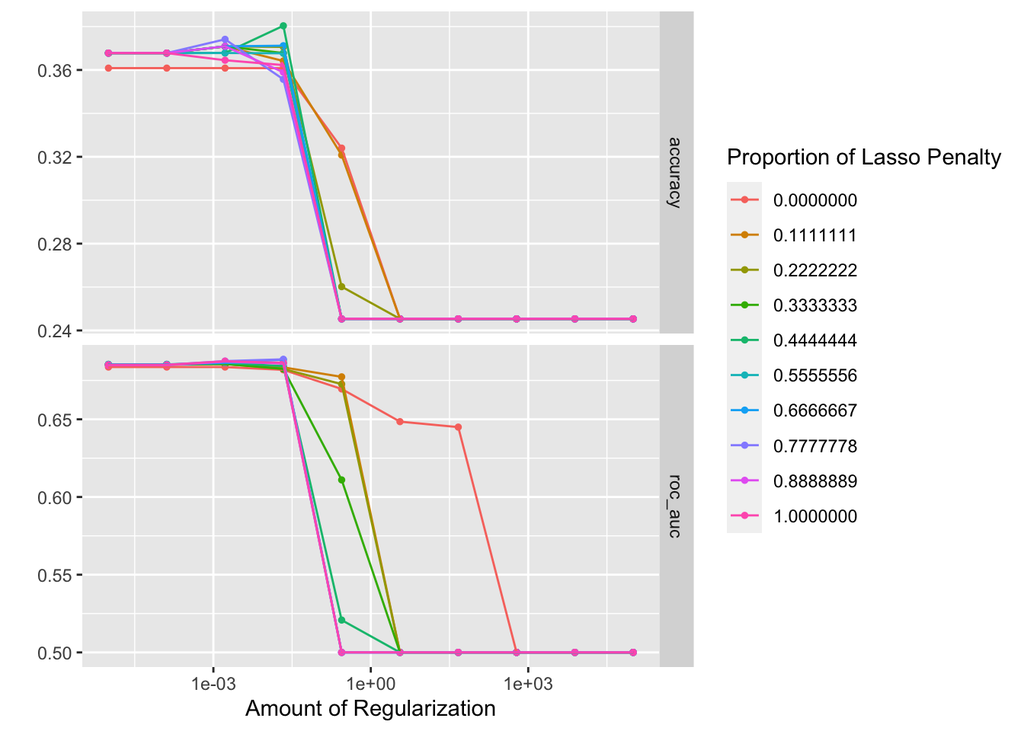

```r
pokemon_res <- tune_grid(
  pokemon_wf,
  resamples = pokemon_fold,
  grid = reg_grid,
  control = control_grid(verbose = TRUE)
)

autoplot(pokemon_res)
```

Smaller values of penalty produce better accuracy and ROC AUC, however for mixture the values differ from 0.444 to 0.777 for better accuracy and ROC AUC respectively.

### Exercise 7

```r
#Choose model with optimal roc_auc
best <- select_best(pokemon_res, metric = "roc_auc")
best
```

```
## # A tibble: 1 × 3
##   penalty mixture .config
##     <dbl>   <dbl> <chr>
## 1  0.0215   0.778 Preprocessor1_Model074
```

```r
#Fit model to training set
pokemon_final <- finalize_workflow(pokemon_wf, best)
pokemon_final_fit <- fit(pokemon_final, data = pokemon_train)

#Evaluate training set
multi_metric <- metric_set(accuracy, sensitivity, specificity)
augment(pokemon_final_fit, new_data = pokemon_train) %>%
  multi_metric(truth = type_1, estimate = .pred_class)
```

```
## # A tibble: 3 × 3
##   .metric     .estimator .estimate
##   <chr>       <chr>          <dbl>
## 1 accuracy    multiclass     0.406
## 2 sensitivity macro          0.361
## 3 specificity macro          0.874
```

```r
#Evaluate testing set
augment(pokemon_final_fit, new_data = pokemon_test) %>%
  multi_metric(truth = type_1, estimate = .pred_class)
```

```
## # A tibble: 3 × 3
##   .metric     .estimator .estimate
##   <chr>       <chr>          <dbl>
## 1 accuracy    multiclass     0.371
## 2 sensitivity macro          0.315
## 3 specificity macro          0.867
```

### Exercise 8

```r
library(yardstick)
# Overall ROC AUC
augment(pokemon_final_fit, new_data = pokemon_test) %>%
  roc_auc(truth = type_1, .pred_Bug, .pred_Fire, .pred_Grass, .pred_Normal, .pred_Psychic, .pred_Water)
```

```
## # A tibble: 1 × 3
##   .metric .estimator .estimate
##   <chr>   <chr>          <dbl>
## 1 roc_auc hand_till      0.704
```

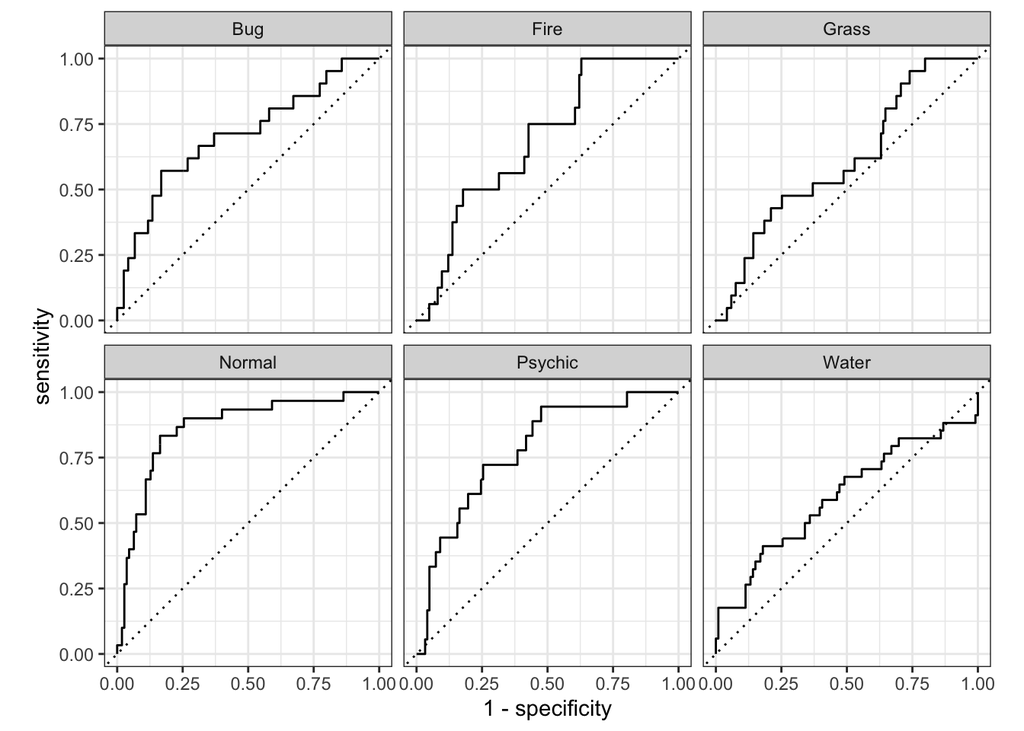

```r
# Plots
augment(pokemon_final_fit, new_data = pokemon_test) %>%
  roc_curve(truth = type_1, .pred_Bug, .pred_Fire, .pred_Grass, .pred_Normal, .pred_Psychic, .pred_Water) %>%
  autoplot()
```

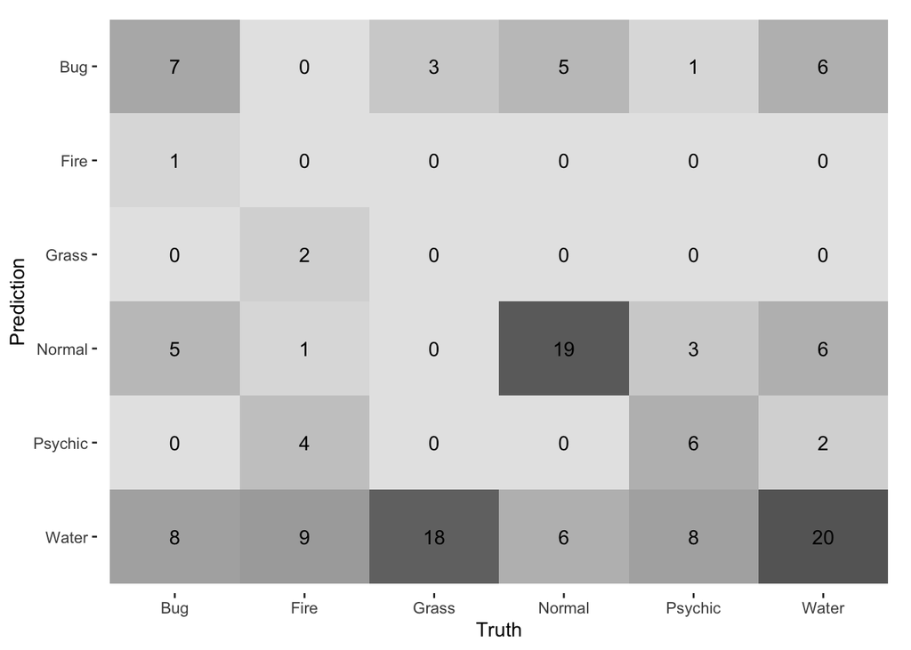

```r
# Heatmap of Confusion Matrix
augment(pokemon_final_fit, new_data = pokemon_test) %>%
  conf_mat(truth = type_1, estimate = .pred_class) %>%
  autoplot(type = "heatmap")
```

Based off the heatmap, the model does the best at predicting Normal and Water types, and its the worst at predicting Fire, and Grass. Based off the plots for the different ROC curves, Normal types makes sense on why it is the best at predicting it correctly, however it does not make much sense for the Water type since the ROC curve seems to be low. It also seems that the model overpredicts the type Water for all the other types as well.